# User Guide for *shinyGEM*

O’Connor G, Melton P, Huang RC, Lin A, Nair G, Rauschert S 28 November 2019

# Introduction

We aimed to build an easy to use package for wider application in the research community, enabling non-bioinformaticians to perform epigenome/genome wide association studies.

The package includes two main functions. One to perform an EWAS in terminal or in RStudio, the other one to perform the analysis in a graphical user interface.

To use the terminal based program, use the following function:

- `shinyGEM_Emodel()`

To start the interactive graphical user interface, type the following in the R console or in RStudio:

- `shinyGEM()`

# How to

## Installation

The package requires the `devtools` package, which is not always installed on Windows machines. Install the `devtools` package the following way:

```r
install.packages("devtools")
```

After successful installation, you can now proceed to install the `shinyGEM` package:

```r
devtools::install_github("Hobbeist/shinyGEM", build_vignettes=T)
```

# Basic example

Lets assume you have an epigenetic data set on the same computer/virtual machine, that you are using R/RStudio on. The data should look something like this:

## Methylation data

The methylation data needs to be in the following format:

- columns: IDs
- rows: CpG identifiers

Note: the function `shinyGEM_Emodel()` will handle the reformatting of the data for modelling. This includes making the first column the rownames of the data.

```r
meth[1:10,1:10]
```

```
##            ID         1         2          3         4          5
## 1  cg13869341 0.8485763 0.5500894 0.12850758 0.2051441 0.09459159
## 2  cg14008030 0.8140296 0.5537720 0.12540615 0.1417291 0.07259534
## 3  cg12045430 0.8493949 0.5876479 0.13621964 0.1188400 0.08619664
## 4  cg20826792 0.8140191 0.5055042 0.08382295 0.2450263 0.09480168
## 5  cg00381604 0.8932565 0.5718941 0.10419281 0.2033953 0.06451720
## 6  cg20253340 0.8536898 0.5762568 0.12601606 0.1857902 0.10135914
## 7  cg21870274 0.8374118 0.6865726 0.09817245 0.1499010 0.07035129
## 8  cg24335620 0.8726548 0.6289168 0.11657413 0.1385870 0.10694088
## 9  cg16162899 0.8215087 0.5015078 0.11264902 0.1808743 0.10562128
## 10 cg17149495 0.8147909 0.4913580 0.08971687 0.1685671 0.08460352
##            6         7         8         9
## 1  0.4799144 0.8425724 0.8115371 0.7850983
## 2  0.4988177 0.7662237 0.8630842 0.7598750
## 3  0.5904106 0.7425055 0.8042310 0.7386192
## 4  0.5115217 0.7569133 0.7909643 0.8072275
## 5  0.5224439 0.7965759 0.8186969 0.8455681
## 6  0.5083808 0.8133820 0.8535415 0.8102541
## 7  0.5929781 0.8031981 0.8075276 0.8664824
## 8  0.6149991 0.7312164 0.7538832 0.9143900
## 9  0.4821197 0.7830431 0.8830173 0.7360199
## 10 0.4859621 0.7878866 0.8411788 0.8688017
```

## Covariate data

The covariate data needs to contain the same participant IDs as the DNA methylation data. the `shinyGEM_Emodel()` function will automatically select the overlapping IDs between the two data sets and arrange the data accordingly, as the IDs need to be in the same order in both data sets.

Important note: The `shinyGEM` model only takes numerical variables as input, so make sure all variabels are represented by numbers, which is especially important for categorical variables.

This does not apply for the batch variable (Plate_no in the example), as this variable will only be used for the batch correction, leveraging the `sva` packages `Combat` method.

```r
as.data.frame(covar[1:10,])
```

```
##    ID sex      BMI preg_smoking      Gran       Mono      Bcell
## 1   1   1 25.43432            0 0.4925295 0.11375363 0.06192109
## 2   2   0 21.41809            0 0.4711842 0.02861025 0.06163826
## 3   3   1 25.52949            0 0.4016132 0.09238381 0.08854669
## 4   4   1 21.41687            1 0.7176768 0.03836773 0.04068093
## 5   5   0 30.62862            0 0.4931266 0.06147346 0.10850030
## 6   6   0 26.02879            0 0.5637986 0.12027336 0.09975753
## 7   7   0 24.13639            0 0.5987908 0.07335051 0.12667617
## 8   8   0 28.23357            0 0.6309122 0.06999387 0.05286140
## 9   9   0 22.28757            0 0.5541438 0.10455315 0.05913990
## 10 10   1 21.50660            0 0.4917726 0.07195334 0.04998885
##              NK      CD4T       CD8T  Plate_no
## 1   0.025615730 0.2199097 0.04863577 WG0025205
## 2  -0.049208797 0.2481194 0.09716254 WG0025141
## 3   0.044705860 0.2396132 0.04269554 WG0023131
## 4   0.034093459 0.1080412 0.07135086 WG0025205
## 5   0.055181022 0.1688519 0.06660063 WG0025142
## 6  -0.036667570 0.2372782 0.08417902 WG0025205
## 7   0.038567614 0.2609767 0.11073692 WG0022068
## 8  -0.065478365 0.2173655 0.14381208 WG0025142
## 9  -0.002382703 0.1572995 0.07941002 WG0021926
## 10  0.076970117 0.1337072 0.07582930 WG0025111
```

Note: As the methylation data frame will be severa gigabyte large, it is not necessary to load the data frames into R before modelling. The `shinyGEM_Emodel()` function take the path to both the covariate and the epigenetic data files as arguments and loads them.

## Model the data

When you made sure that the covariate and the methylation data are in the format as above, you can start with the model. We will use the terminal/R code first, before diving into the user interface.

The function we will use is:  
`shinyGEM_Emodel(envFileName, methylFileName,predictorName, batchName = FALSE, covName = NULL, qqplotInclude = TRUE)`

For this function, we need to specify the following:

`envFileName`: This is the path to the covaraite and predictor data frame (covar above)

`methylFileName`: Just like for the covariates file, here we need to specify the path for the methylation data

`predictorName`: This is a character, naming the the predictor variabel for our model, e.g. `preg_smoking` in our data example

`batchName`: A character naming the batch variable for batch correction, e.g. `Plate_no` in our example. Note: if this stays `FALSE`, batch correction will not be included

`covName`: Here teh user can specify a covariate variable or a vector of covariates to be included in the model. Note: the covariates all need to be numeric, as noted above.

`qqplotInclude`: By default, teh modelling process will include a qqplot of the p-values.

Note: to store the model results (a list of the result table and the qqplot), don’t forget to assign it, like so:

`resultsEWAS <- shinyGEM_Emodel(envFileName, methylFileName,predictorName, batchName = FALSE, covName = NULL, qqplotInclude = TRUE)`)

```r
#setwd("~/Desktop/")
results <- shinyGEM_Emodel(envFileName = "~/Desktop/covar_2.txt",
                           methylFileName = "~/Desktop/meth_2.txt",
                           predictorName = "preg_smoking")
```

```
## 100.00% done, 1,000 CpGs
## Analysis done in:  0.105  seconds
```

The table results:

```r
results$resultTable[1:10,]
```

```
##           cpg               beta             stats               pvalue
## 1  cg15736449 -0.372622706948931  -16.798231132794 7.06520325282874e-56
## 2  cg23087108  0.513763181611946  16.5746858512873 1.30794794886358e-54
## 3  cg10824915 -0.349920351324207 -15.6209204413013 2.60121726949484e-49
## 4  cg05706898  0.446213312990897  14.8628982474011 3.10624944077163e-45
## 5  cg19856606  0.415219817873647  14.0883926526834 3.35548926870462e-41
## 6  cg08621441  0.370569371493333  12.7338129691342 1.70499060180548e-34
## 7  cg00299257 -0.182627940933357 -7.89981665675044 7.43562296224679e-15
## 8  cg17308840  0.139561158933151  5.34029673727087 1.15236653229769e-07
## 9  cg09756115  -0.11109606044307 -4.67929098997973 3.28067652152921e-06
## 10 cg24598973 0.0308548514353143  1.24692069744529    0.212722991957428
##                     FDR
## 1  7.06520325282874e-53
## 2  6.53973974431788e-52
## 3  8.67072423164948e-47
## 4  7.76562360192908e-43
## 5  6.71097853740923e-39
## 6  2.84165100300914e-32
## 7  1.06223185174954e-12
## 8  1.44045816537211e-05
## 9  0.000364519613503245
## 10    0.842102662067462
```

The qqplot:

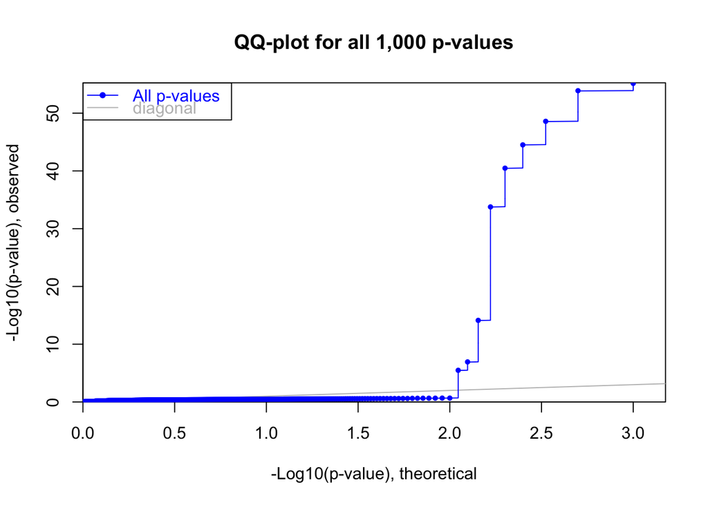

```r
results$qqPlot
```

## Visualization

The package contains a fucntion to create a volcano plot. It works in the following way:

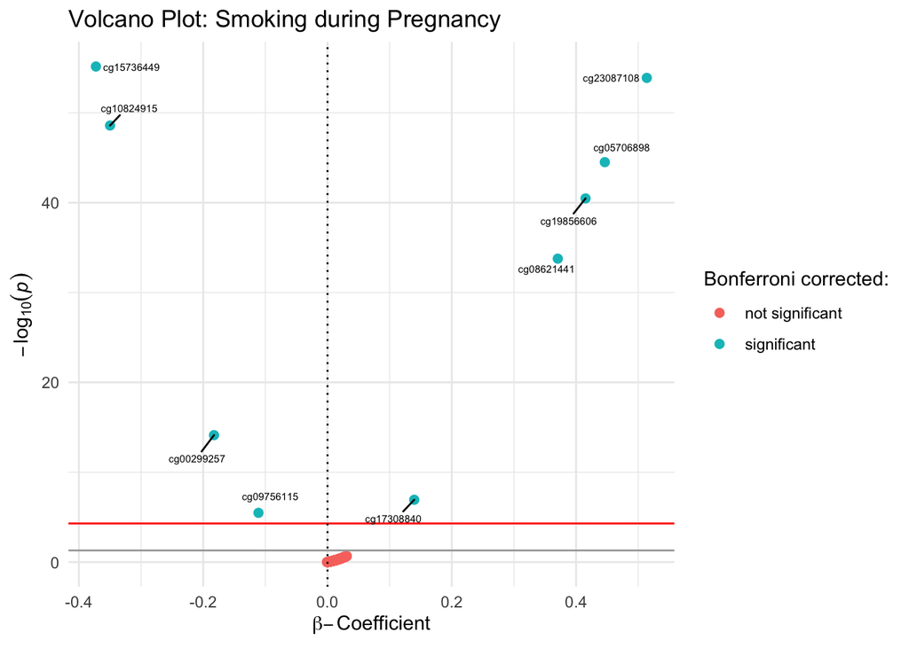

```r
VolcanoPlot(results$resultTable, title="Volcano Plot: Smoking during Pregnancy")
```

# The Shiny app

For users that are not too comfortable with the terminal environment or coding in R, the package includes a shiny app. This app can easily be started by typing `shinyGEM()` in the R console.

This will open up the following window:

[figure not shown]

Fig 1: The shiny interface

On the lefthandside, click “Dashboard”, to get to the applciation screen:

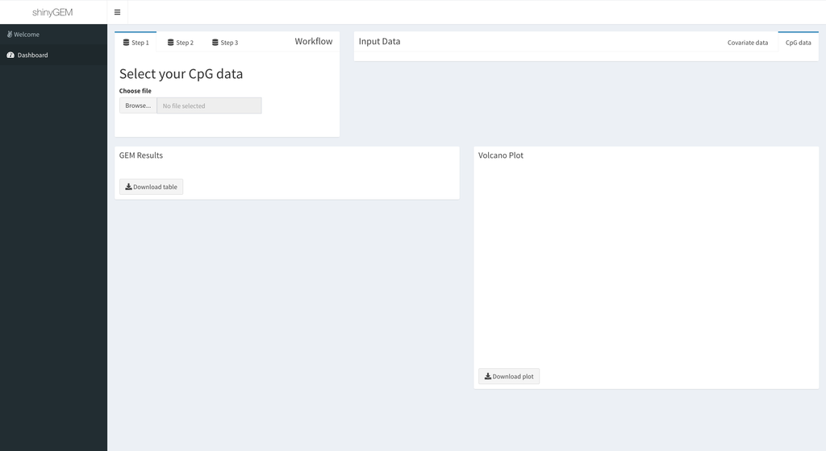

Fig 2: Select input

First, we need to select the methylation data set on the file browser:

[figure not shown]

Fig 3: Select methylation file

Second, , we need to select the covariate data set on the file browser. Here, we also get prompted to select a predictor variable and covariates, if desired:

[figure not shown]

Fig 4: Select covariate file

After this, we need to make some selection before we model: Do we want to adjust for batch? Do we give the Volcano plot a distinct header?

[figure not shown]

Fig 6: Final settings

After pressing the “Start GEM Model” button, we have to wait a bit until we get the result output: a volcano plot and the result table. Both can be downloaded via the app.

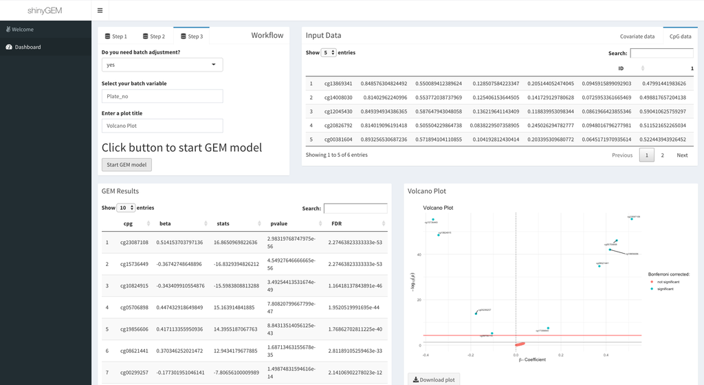

# R Session Info

**R version 3.6.1 (2019-07-05)**

**Platform:** x86_64-apple-darwin15.6.0 (64-bit)

**locale:** en_AU.UTF-8||en_AU.UTF-8||en_AU.UTF-8||C||en_AU.UTF-8||en_AU.UTF-8

**attached base packages:**

- stats
- graphics
- grDevices
- utils
- datasets
- methods
- base

**other attached packages:**

- pander(v.0.6.3)
- shinyGEM(v.0.1.0)
- forcats(v.0.3.0)
- stringr(v.1.4.0)
- dplyr(v.0.8.0.1)
- purrr(v.0.3.3)
- readr(v.1.1.1)
- tidyr(v.0.8.3.9000)
- tibble(v.2.1.3)
- ggplot2(v.3.2.1)
- tidyverse(v.1.2.1)

**loaded via a namespace (and not attached):**

A work by O’Connor G, Melton P, Huang RC, Lin A, Nair G, Rauschert S